# Assignment2_RyanMurray

##### Ryan Murray

- xhs-290

### Assignment 2

#### Chapter 03 (page 121): 2, 9, 10, 12

#### 2. Carefully explain the differences between the KNN classifier and KNN regression methods.

> Both methods are used for prediction. The KNN classifier method deals with binary type of predictions, Yes, No or Alive, Dead for example. The KNN regression methods deals with predictions that want to know the price, sales, or other calculation to predict a number. Both methods look a value like the price of a home, and then draws a imaginary circle around it's K nearest neighbors. The group that is formed is then either calculaed usually by taking the average of all of the values and then using that number to predict the value. Classification is very similar except instead of taking the average it takes a count or Yes vs No's or True or False and uses that to determine the prediction.

#### 9. This question involves the use of multiple linear regression on the Auto data set.

**(a) Produce a scatterplot matrix which includes all of the variables in the data set.**

```python
#!pip install Pandas
```

```python
import pandas as pd
Auto = pd.read_csv('Auto.csv')

#Auto.tail()
# Auto.info()
```

```python
import matplotlib.pyplot as plt
import seaborn as sns

import numpy as np

Auto['horsepower'] = Auto['horsepower'].replace('?', np.nan)
Auto['horsepower'] = pd.to_numeric(Auto['horsepower'])

Auto_clean = Auto.dropna()
```

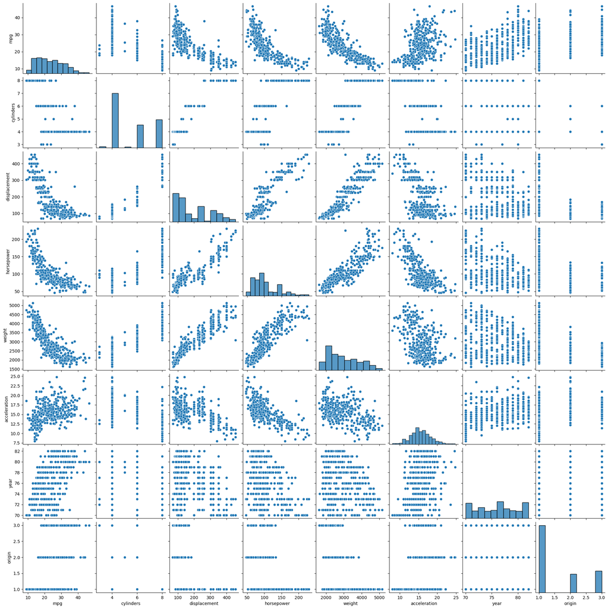

```python
sns.pairplot(Auto_clean)

plt.show()
```

**(b) Compute the matrix of correlations between the variables using the DataFrame.corr() method. .corr()**

```python
numeric_auto = Auto_clean.drop(columns=['name'])
correlation_matrix = numeric_auto.corr()

correlation_matrix
```

|  | mpg | cylinders | displacement | horsepower | weight | acceleration | year | origin |
| --- | --- | --- | --- | --- | --- | --- | --- | --- |
| mpg | 1.000000 | -0.777618 | -0.805127 | -0.778427 | -0.832244 | 0.423329 | 0.580541 | 0.565209 |
| cylinders | -0.777618 | 1.000000 | 0.950823 | 0.842983 | 0.897527 | -0.504683 | -0.345647 | -0.568932 |
| displacement | -0.805127 | 0.950823 | 1.000000 | 0.897257 | 0.932994 | -0.543800 | -0.369855 | -0.614535 |
| horsepower | -0.778427 | 0.842983 | 0.897257 | 1.000000 | 0.864538 | -0.689196 | -0.416361 | -0.455171 |
| weight | -0.832244 | 0.897527 | 0.932994 | 0.864538 | 1.000000 | -0.416839 | -0.309120 | -0.585005 |
| acceleration | 0.423329 | -0.504683 | -0.543800 | -0.689196 | -0.416839 | 1.000000 | 0.290316 | 0.212746 |
| year | 0.580541 | -0.345647 | -0.369855 | -0.416361 | -0.309120 | 0.290316 | 1.000000 | 0.181528 |
| origin | 0.565209 | -0.568932 | -0.614535 | -0.455171 | -0.585005 | 0.212746 | 0.181528 | 1.000000 |

**(c) Use the sm.OLS() function to perform a multiple linear regression with mpg as the response and all other variables except name as the predictors. Use the summarize() function to print the results. Comment on the output.**

##### **For instance:**

- **i. Is there a relationship between the predictors and the re- sponse? Use the anova_lm() function from statsmodels to answer this question.**
- **ii. Which predictors appear to have a statistically significant relationship to the response?**
- **iii. What does the coefficient for the year variable suggest?**

```python
numeric_auto.columns
```

```
Index(['mpg', 'cylinders', 'displacement', 'horsepower', 'weight',
       'acceleration', 'year', 'origin'],
      dtype='object')
```

```python
#from ISLP.models import ModelSpec as MS, summarize, poly, qualitative_or_quantitative
from statsmodels .stats. outliers_influence \
import variance_inflation_factor as VIF
from statsmodels .stats.anova import anova_lm
from ISLP.models import ModelSpec as MS, summarize, poly
from ISLP import load_data
import statsmodels.api as sm

Auto_clean['origin'] = Auto_clean['origin'].astype('category')

terms = [ 'cylinders', 'displacement', 'horsepower', 'weight',
       'acceleration', 'year', 'origin']

y = Auto_clean['mpg']
X = MS(terms).fit_transform(Auto_clean)
model1 = sm.OLS(y, X)
results1 = model1.fit()
summarize(results1)
```

|  | coef | std err | t | P>\|t\| |
| --- | --- | --- | --- | --- |
| intercept | -17.9546 | 4.677 | -3.839 | 0.000 |
| cylinders | -0.4897 | 0.321 | -1.524 | 0.128 |
| displacement | 0.0240 | 0.008 | 3.133 | 0.002 |
| horsepower | -0.0182 | 0.014 | -1.326 | 0.185 |
| weight | -0.0067 | 0.001 | -10.243 | 0.000 |
| acceleration | 0.0791 | 0.098 | 0.805 | 0.421 |
| year | 0.7770 | 0.052 | 15.005 | 0.000 |
| origin[2] | 2.6300 | 0.566 | 4.643 | 0.000 |
| origin[3] | 2.8532 | 0.553 | 5.162 | 0.000 |

```python
# same as above using Patsy version and treating the origin properly as a classification predictor
full_model = smf.ols(formula='mpg ~ cylinders + displacement + horsepower + acceleration + year + C(origin) + weight', data=Auto_clean).fit()
print(full_model.summary())
```

```
                            OLS Regression Results
==============================================================================
Dep. Variable:                    mpg   R-squared:                       0.824
Model:                            OLS   Adj. R-squared:                  0.821
Method:                 Least Squares   F-statistic:                     224.5
Date:                Sun, 21 Jun 2026   Prob (F-statistic):          1.79e-139
Time:                        12:26:04   Log-Likelihood:                -1020.5
No. Observations:                 392   AIC:                             2059.
Df Residuals:                     383   BIC:                             2095.
Df Model:                           8
Covariance Type:            nonrobust
==================================================================================
                     coef    std err          t      P>|t|      [0.025      0.975]
----------------------------------------------------------------------------------
Intercept        -17.9546      4.677     -3.839      0.000     -27.150      -8.759
C(origin)[T.2]     2.6300      0.566      4.643      0.000       1.516       3.744
C(origin)[T.3]     2.8532      0.553      5.162      0.000       1.766       3.940
cylinders         -0.4897      0.321     -1.524      0.128      -1.121       0.142
displacement       0.0240      0.008      3.133      0.002       0.009       0.039
horsepower        -0.0182      0.014     -1.326      0.185      -0.045       0.009
acceleration       0.0791      0.098      0.805      0.421      -0.114       0.272
year               0.7770      0.052     15.005      0.000       0.675       0.879
weight            -0.0067      0.001    -10.243      0.000      -0.008      -0.005
==============================================================================
Omnibus:                       23.395   Durbin-Watson:                   1.291
Prob(Omnibus):                  0.000   Jarque-Bera (JB):               34.452
Skew:                           0.444   Prob(JB):                     3.30e-08
Kurtosis:                       4.150   Cond. No.                     8.70e+04
==============================================================================

Notes:
[1] Standard Errors assume that the covariance matrix of the errors is correctly specified.
[2] The condition number is large, 8.7e+04. This might indicate that there are
strong multicollinearity or other numerical problems.
```

```python
# ANOVA running against the null model

terms2 = []
X = MS(terms2).fit_transform(Auto_clean)
model2  = sm.OLS(y, X)
null_model = model2.fit()
summarize(null_model)
anova_lm(null_model, results1)
```

|  | df_resid | ssr | df_diff | ss_diff | F | Pr(>F) |
| --- | --- | --- | --- | --- | --- | --- |
| 0 | 391.0 | 23818.993469 | 0.0 | NaN | NaN | NaN |
| 1 | 383.0 | 4187.391678 | 8.0 | 19631.601791 | 224.450686 | 1.789724e-139 |

#### iii. What does the coefficient for the year variable suggest?

> Year coefficient = 0.7770  
> Holding all other variable fixed, for every 1 year increase in the model year of the car (newer) we can associate a 0.77 increase in miles per gallon.

**(d) Produce some of diagnostic plots of the linear regression fit as described in the lab. Comment on any problems you see with the fit.**

- **Do the residual plots suggest any unusually large outliers?**
- **Does the leverage plot identify any observations with unusually high leverage?**

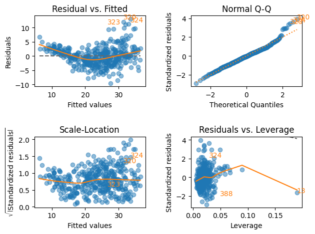

```python
import lmdiag
import matplotlib.pyplot as plt

lmdiag.plot(results1)
plt.show()
```

**(e) Fit some models with interactions as described in the lab. Do any interactions appear to be statistically significant?**

```
                            OLS Regression Results
==============================================================================
Dep. Variable:                    mpg   R-squared:                       0.861
Model:                            OLS   Adj. R-squared:                  0.859
Method:                 Least Squares   F-statistic:                     340.7
Date:                Sat, 20 Jun 2026   Prob (F-statistic):          1.99e-160
Time:                        12:09:42   Log-Likelihood:                -973.97
No. Observations:                 392   AIC:                             1964.
Df Residuals:                     384   BIC:                             1996.
Df Model:                           7
Covariance Type:            nonrobust
========================================================================================
                           coef    std err          t      P>|t|      [0.025      0.975]
----------------------------------------------------------------------------------------
Intercept                6.7241      4.359      1.543      0.124      -1.846      15.294
C(origin)[T.2]           1.4134      0.475      2.975      0.003       0.479       2.347
C(origin)[T.3]           1.7885      0.468      3.818      0.000       0.867       2.710
cylinders               -4.0020      0.441     -9.068      0.000      -4.870      -3.134
horsepower              -0.2853      0.027    -10.572      0.000      -0.338      -0.232
cylinders:horsepower     0.0381      0.004     10.752      0.000       0.031       0.045
year                     0.7565      0.046     16.605      0.000       0.667       0.846
weight                  -0.0046      0.000     -9.492      0.000      -0.005      -0.004
==============================================================================
Omnibus:                       32.886   Durbin-Watson:                   1.573
Prob(Omnibus):                  0.000   Jarque-Bera (JB):               56.310
Skew:                           0.533   Prob(JB):                     5.92e-13
Kurtosis:                       4.520   Cond. No.                     9.37e+04
==============================================================================

Notes:
[1] Standard Errors assume that the covariance matrix of the errors is correctly specified.
[2] The condition number is large, 9.37e+04. This might indicate that there are
strong multicollinearity or other numerical problems.
```

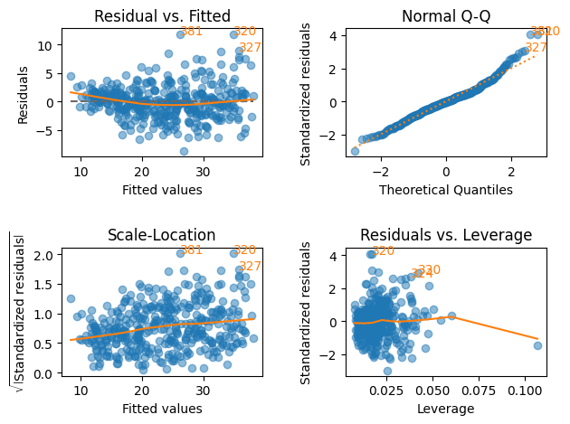

```python
import statsmodels.formula.api as smf
import matplotlib.pyplot as plt

# Fix: Reset index so row labels are perfectly sequential
Auto_clean = Auto_clean.reset_index(drop=True)

# using the Patsy formula instead of the one presented in ISLP because it feels more familiar coming from R.
interaction_model = smf.ols(formula='mpg ~ cylinders * horsepower + year + C(origin) + weight', data=Auto_clean).fit()
print(interaction_model.summary())
lmdiag.plot(interaction_model)
plt.show()
```

> After keeping the values from the full model with a P value of 0.00 (year, origin, weight), I also created a interaction between horsepower and cylinders. The interaction changed these two variables to have a P value of 0.00 saying these predictors together have a combined effect that is statistcally significant. Now we can say: While both an increase in cylinders and an increase in horsepower individually reduce fuel efficiency, their negative impacts diminish when combined. Specifically, for every additional cylinder an engine has, the negative effect of horsepower on mpg is mitigated (becomes less negative) by 0.0381 units.

**(f) Try a few different transformations of the variables, such as log(X), √X, X2. Comment on your findings.**

```python
from scipy.stats import boxcox

# 1. Find the optimal lambda and generate the transformed array
# Note: y (mpg) must be strictly positive (> 0)
y_transformed, optimal_lambda = boxcox(Auto_clean['mpg'])

print(f"Optimal Box-Cox Lambda: {optimal_lambda:.4f}")


# Add the transformed target back into your dataframe
Auto_clean['mpg_boxcox'] = y_transformed

# 3. Fit your model cleanly using Patsy formulas
boxcox_model = smf.ols(
    formula='mpg_boxcox ~ cylinders + horsepower + weight + C(origin)',
    data=Auto_clean
).fit()

print(boxcox_model.summary())
```

```
Optimal Box-Cox Lambda: 0.1912
                            OLS Regression Results
==============================================================================
Dep. Variable:             mpg_boxcox   R-squared:                       0.785
Model:                            OLS   Adj. R-squared:                  0.782
Method:                 Least Squares   F-statistic:                     281.8
Date:                Sat, 20 Jun 2026   Prob (F-statistic):          2.15e-126
Time:                        11:48:18   Log-Likelihood:                -63.073
No. Observations:                 392   AIC:                             138.1
Df Residuals:                     386   BIC:                             162.0
Df Model:                           5
Covariance Type:            nonrobust
==================================================================================
                     coef    std err          t      P>|t|      [0.025      0.975]
----------------------------------------------------------------------------------
Intercept          5.9210      0.078     76.075      0.000       5.768       6.074
C(origin)[T.2]     0.0375      0.046      0.823      0.411      -0.052       0.127
C(origin)[T.3]     0.1523      0.045      3.352      0.001       0.063       0.242
cylinders         -0.0344      0.021     -1.651      0.100      -0.075       0.007
horsepower        -0.0044      0.001     -5.504      0.000      -0.006      -0.003
weight            -0.0004   4.51e-05     -7.928      0.000      -0.000      -0.000
==============================================================================
Omnibus:                        6.483   Durbin-Watson:                   0.907
Prob(Omnibus):                  0.039   Jarque-Bera (JB):                6.639
Skew:                           0.241   Prob(JB):                       0.0362
Kurtosis:                       3.417   Cond. No.                     1.91e+04
==============================================================================

Notes:
[1] Standard Errors assume that the covariance matrix of the errors is correctly specified.
[2] The condition number is large, 1.91e+04. This might indicate that there are
strong multicollinearity or other numerical problems.
```

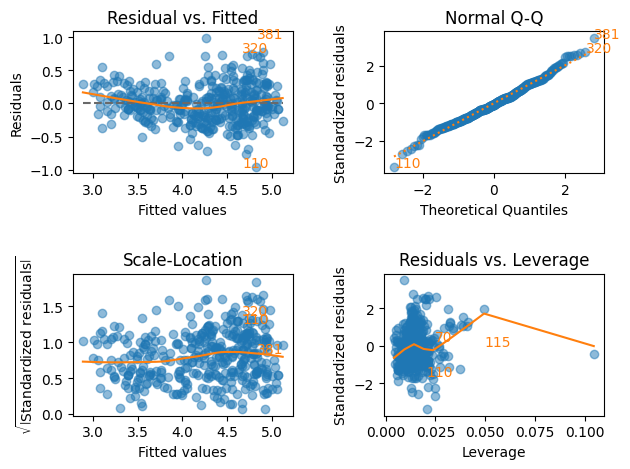

```python
lmdiag.plot(boxcox_model)
plt.show()
```

#### Box-Cox Transformation Analysis

> - Running a Box-Cox test identifies an optimal $\lambda $ (lambda) value of 0.192. Applying this power transformation stabilizes variance and normalizes the target variable ((y)). Because a lambda of 0.192 is close to 0, it strongly indicates that a natural log $ \ln $ transformation is appropriate and mathematically justifiable for normalizing this data.

#### Diagnostic Plot Interpretations

```
                            OLS Regression Results
==============================================================================
Dep. Variable:                    mpg   R-squared:                       0.828
Model:                            OLS   Adj. R-squared:                  0.826
Method:                 Least Squares   F-statistic:                     372.1
Date:                Sun, 21 Jun 2026   Prob (F-statistic):          3.57e-145
Time:                        13:01:11   Log-Likelihood:                -1016.0
No. Observations:                 392   AIC:                             2044.
Df Residuals:                     386   BIC:                             2068.
Df Model:                           5
Covariance Type:            nonrobust
======================================================================================
                         coef    std err          t      P>|t|      [0.025      0.975]
--------------------------------------------------------------------------------------
Intercept              3.8931      6.271      0.621      0.535      -8.437      16.223
C(origin)[T.2]         1.7413      0.508      3.428      0.001       0.743       2.740
C(origin)[T.3]         2.4340      0.508      4.787      0.000       1.434       3.434
np.log(horsepower)    -4.7775      1.054     -4.535      0.000      -6.849      -2.706
year                   0.7027      0.050     14.127      0.000       0.605       0.800
weight                -0.0043      0.000     -9.750      0.000      -0.005      -0.003
==============================================================================
Omnibus:                       26.146   Durbin-Watson:                   1.297
Prob(Omnibus):                  0.000   Jarque-Bera (JB):               37.483
Skew:                           0.497   Prob(JB):                     7.26e-09
Kurtosis:                       4.143   Cond. No.                     1.19e+05
==============================================================================

Notes:
[1] Standard Errors assume that the covariance matrix of the errors is correctly specified.
[2] The condition number is large, 1.19e+05. This might indicate that there are
strong multicollinearity or other numerical problems.
```

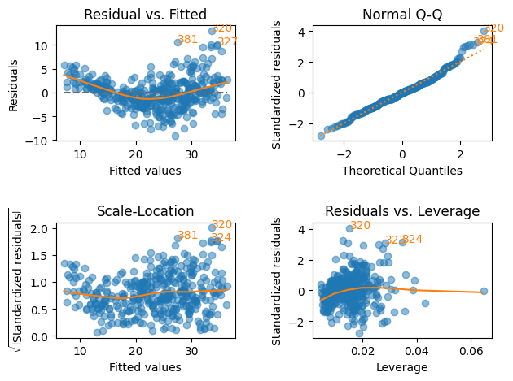

```python
transform_model = smf.ols(formula='mpg ~ np.log(horsepower) + year + C(origin) + weight', data=Auto_clean).fit()
print(transform_model.summary())
lmdiag.plot(transform_model)
plt.show()
```

#### Log Transform of the horsepower variable

> - Here I did not apply the lambda transform to the y variable like in the previous model. Instead I looked to see what variable might benefit the most from a log transform which I determined to be horsepower. I also removed cylinders as this variable was not significant. After the transform of horsepower using natural log and removal of cylinders, the R squared value increase to 0.82 or 82% showing an improvement of the models accuracy. All retained variables in this model are significant wiht a p value of 0.00.
> - horsepower's coefficient significantly changed from -0.0044 to -4.775. The interpretation requires some math. I divided the coefficient by 100 to get -0.04775, rounded the number and the negative is described as a 'decrease'.
> - For every 1% increase in a vehicle's horsepower, its fuel economy (MPG) is expected to decrease by approximately 0.048 units, holding all other variables constant.

#### Diagnostic Plots

> - The Residual vs Fitted plot actually worsened and the deep bow in the plot indicates the log transform had a dramatic impact but failed to capture all of the outlying terms which means either the log transform was done on the wrong variable or more work needs to be done to address the outliers and the dispersment of the fitted values.
> - The Normal Q-Q plot is actually fine as most of the values fall along the line with only some of the values breaking away on the top tail. This again seems to indicate some influence from outliers.
> - Scale-Location plot indicates it is generally ok as far as heterscedasticity goes but the slight bump and elevated line from the middle to the left still shows some influence from outliers
> - Residuals vs Leverage this plot showed the most significant improvement. By log-transforming Horsepower, extreme predictor values were brought closer to the distribution center, successfully neutralizing severe leverage. While a few outliers remain at the top of the plot—exerting a minor upward pull on the left side of the trendline—their influence is heavily mitigated. Addressing these remaining extreme data points remains a logical next step.

### 10. This question should be answered using the Carseats data set.

**(a) Fit a multiple regression model to predict Sales using Price, Urban, and US.**

```python
#%pip install ISLP
from ISLP import load_data

carseats = load_data('Carseats')
carseats.info()
carseats.head()
```

```
<class 'pandas.core.frame.DataFrame'>
RangeIndex: 400 entries, 0 to 399
Data columns (total 11 columns):
 #   Column       Non-Null Count  Dtype
---  ------       --------------  -----
 0   Sales        400 non-null    float64
 1   CompPrice    400 non-null    int64
 2   Income       400 non-null    int64
 3   Advertising  400 non-null    int64
 4   Population   400 non-null    int64
 5   Price        400 non-null    int64
 6   ShelveLoc    400 non-null    category
 7   Age          400 non-null    int64
 8   Education    400 non-null    int64
 9   Urban        400 non-null    category
 10  US           400 non-null    category
dtypes: category(3), float64(1), int64(7)
memory usage: 26.7 KB
```

|  | Sales | CompPrice | Income | Advertising | Population | Price | ShelveLoc | Age | Education | Urban | US |
| --- | --- | --- | --- | --- | --- | --- | --- | --- | --- | --- | --- |
| 0 | 9.50 | 138 | 73 | 11 | 276 | 120 | Bad | 42 | 17 | Yes | Yes |
| 1 | 11.22 | 111 | 48 | 16 | 260 | 83 | Good | 65 | 10 | Yes | Yes |
| 2 | 10.06 | 113 | 35 | 10 | 269 | 80 | Medium | 59 | 12 | Yes | Yes |
| 3 | 7.40 | 117 | 100 | 4 | 466 | 97 | Medium | 55 | 14 | Yes | Yes |
| 4 | 4.15 | 141 | 64 | 3 | 340 | 128 | Bad | 38 | 13 | Yes | No |

```python
import statsmodels.api as sm
import sklearn
```

```python
#%pip install statsmodels scikit-learn
import statsmodels.formula.api as smf

formula = "Sales ~ Price + Urban + US"

# Fit the model
model = smf.ols(formula=formula, data=carseats).fit()

# View summary statistics (R-squared, p-values)
print(model.summary())
```

```
                            OLS Regression Results
==============================================================================
Dep. Variable:                  Sales   R-squared:                       0.239
Model:                            OLS   Adj. R-squared:                  0.234
Method:                 Least Squares   F-statistic:                     41.52
Date:                Thu, 11 Jun 2026   Prob (F-statistic):           2.39e-23
Time:                        18:19:15   Log-Likelihood:                -927.66
No. Observations:                 400   AIC:                             1863.
Df Residuals:                     396   BIC:                             1879.
Df Model:                           3
Covariance Type:            nonrobust
================================================================================
                   coef    std err          t      P>|t|      [0.025      0.975]
--------------------------------------------------------------------------------
Intercept       13.0435      0.651     20.036      0.000      11.764      14.323
Urban[T.Yes]    -0.0219      0.272     -0.081      0.936      -0.556       0.512
US[T.Yes]        1.2006      0.259      4.635      0.000       0.691       1.710
Price           -0.0545      0.005    -10.389      0.000      -0.065      -0.044
==============================================================================
Omnibus:                        0.676   Durbin-Watson:                   1.912
Prob(Omnibus):                  0.713   Jarque-Bera (JB):                0.758
Skew:                           0.093   Prob(JB):                        0.684
Kurtosis:                       2.897   Cond. No.                         628.
==============================================================================

Notes:
[1] Standard Errors assume that the covariance matrix of the errors is correctly specified.
```

**(b) Provide an interpretation of each coefficient in the model. Be careful—some of the variables in the model are qualitative!**

- Holding all other factors constant, when urban is indicates a 'yes', sales go down by 0.02 fewer thousand units. This is not significant at p=0.936.
- Holding all other factors constant, when US is a 'yes', sales go up by 1.20 thousand units. This is highly significant with p=0.000.
- Holding all other factors constant, when price increases by 1 dollar, sales go down by 0.05 thousand units. This is highly significant with p=0.000.

**(c) Write out the model in equation form, being careful to handle the qualitative variables properly.**

> Sales ~ Price + Urban + US

**(d) For which of the predictors can you reject the null hypothesis H0 : βj = 0?**

> Based on the significant p values of both US (Yes) and Price, we can fail to accept to the null hypothesis because these two predictors have shown to have some affect on our dependent variable Sales.

**(e) On the basis of your response to the previous question, fit a smaller model that only uses the predictors for which there is evidence of association with the outcome.**

```python
formula = "Sales ~ Price + US"

# Fit the model
model2 = smf.ols(formula=formula, data=carseats).fit()

# View summary statistics (R-squared, p-values)
print(model2.summary())
```

```
                            OLS Regression Results
==============================================================================
Dep. Variable:                  Sales   R-squared:                       0.239
Model:                            OLS   Adj. R-squared:                  0.235
Method:                 Least Squares   F-statistic:                     62.43
Date:                Thu, 11 Jun 2026   Prob (F-statistic):           2.66e-24
Time:                        22:21:57   Log-Likelihood:                -927.66
No. Observations:                 400   AIC:                             1861.
Df Residuals:                     397   BIC:                             1873.
Df Model:                           2
Covariance Type:            nonrobust
==============================================================================
                 coef    std err          t      P>|t|      [0.025      0.975]
------------------------------------------------------------------------------
Intercept     13.0308      0.631     20.652      0.000      11.790      14.271
US[T.Yes]      1.1996      0.258      4.641      0.000       0.692       1.708
Price         -0.0545      0.005    -10.416      0.000      -0.065      -0.044
==============================================================================
Omnibus:                        0.666   Durbin-Watson:                   1.912
Prob(Omnibus):                  0.717   Jarque-Bera (JB):                0.749
Skew:                           0.092   Prob(JB):                        0.688
Kurtosis:                       2.895   Cond. No.                         607.
==============================================================================

Notes:
[1] Standard Errors assume that the covariance matrix of the errors is correctly specified.
```

**(f) How well do the models in (a) and (e) fit the data?**

> The models in a and e do not fit the data very well as indicated by R-squared at 0.239 for both models. This indicates that the models explain only 23% of the variability in Sales. It reveals that the limited number of variables do not tell the majority of the story and thaty by adding more variables would most likely help to explain variability of Sales.

**(g) Using the model from (e), obtain 95 % confidence intervals for the coefficient(s).**

```python
intervals = model2.conf_int()
print(intervals)
```

```
                  0          1
Intercept  11.79032  14.271265
US[T.Yes]   0.69152   1.707766
Price      -0.06476  -0.044195
```

**(h) Is there evidence of outliers or high leverage observations in the model from (e)?**

```python
#%pip install lmdiag
```

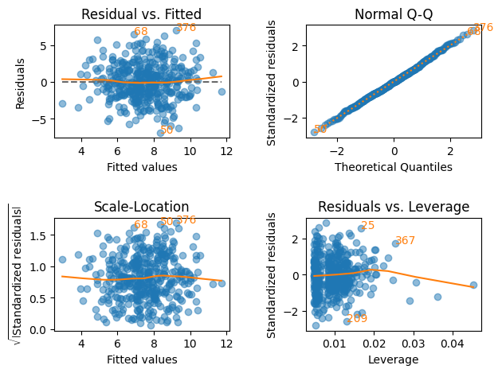

```python
lmdiag.plot(model)
plt.show()
```

#### 12. This problem involves simple linear regression without an intercept.

**(a) Recall that the coefficient estimateˆ β for the linear regression of Y onto X without an intercept is given by (3.38). Under what circumstance is the coefficient estimate for the regression of X onto Y the same as the coefficient estimate for the regression of Y onto X?**

> For regression through the origin,

> $$\hat{\beta}_{Y|X} = \frac{\sum x_i y_i}{\sum x_i^2}$$

> and

> $$\hat{\beta}_{X|Y} = \frac{\sum x_i y_i}{\sum y_i^2}.$$

> These estimates are equal when

> $$\sum x_i^2 = \sum y_i^2,$$

> provided $\sum x_i y_i \neq 0$. A special case is $\sum x_i y_i = 0$, in which case both estimates equal zero.

**(b) Generate an example in Python with n = 100 observations in which the coefficient estimate for the regression of X onto Y is different from the coefficient estimate for the regression of Y onto X.**

```python
import numpy as np
import statsmodels.api as sm

np.random.seed(1)

n = 100
X = np.random.normal(0, 1, n)
Y = 2 * X + np.random.normal(0, 1, n)

# Regression of Y onto X, no intercept
model_y_on_x = sm.OLS(Y, X).fit()

# Regression of X onto Y, no intercept
model_x_on_y = sm.OLS(X, Y).fit()

print("Coefficient for Y onto X:", model_y_on_x.params[0])
print("Coefficient for X onto Y:", model_x_on_y.params[0])
```

```
Coefficient for Y onto X: 2.1067416889591155
Coefficient for X onto Y: 0.37890442290720167
```

**(c) Generate an example in Python with n = 100 observations in which the coefficient estimate for the regression of X onto Y is the same as the coefficient estimate for the regression of Y onto X.**

```python
np.random.seed(1)

n = 100

X = np.random.normal(0, 1, n)
Y = X.copy()

# Y onto X
model_y_on_x = sm.OLS(Y, X).fit()

# X onto Y
model_x_on_y = sm.OLS(X, Y).fit()

print("Coefficient for Y onto X:", model_y_on_x.params[0])
print("Coefficient for X onto Y:", model_x_on_y.params[0])
```

```
Coefficient for Y onto X: 1.0
Coefficient for X onto Y: 1.0
```